# Graphique : les Courbes

- Lire 'unrate.csv' dans un dataframe et assigner ce résultat à la variable unrate.
- Utiliser la fonction pandas.to_datetime() pour convertir la colonne 'DATE' en valeurs datetime.
- Afficher les 12 premières valeurs de unrate correspondant à une année entière.

```python
import pandas as pd

unrate = pd.read_csv("unrate.csv")
unrate['DATE'] = pd.to_datetime(unrate['DATE'])
print(unrate.head(12))
```

```
         DATE  UNRATE
0  1948-01-01     3.4
1  1948-02-01     3.8
2  1948-03-01     4.0
3  1948-04-01     3.9
4  1948-05-01     3.5
5  1948-06-01     3.6
6  1948-07-01     3.6
7  1948-08-01     3.9
8  1948-09-01     3.8
9  1948-10-01     3.7
10 1948-11-01     3.8
11 1948-12-01     4.0
```

## Ajouter des données à nos graphiques

- Générer un graphique linéaire permettant de visualiser les taux de chômage de 1948:
  > - Prendre pour x les 12 premières valeurs de la colonne 'DATE'
  > - Prendre pour y les 12 premières valeurs de la colonne 'UNRATE'
- Afficher le graphique.

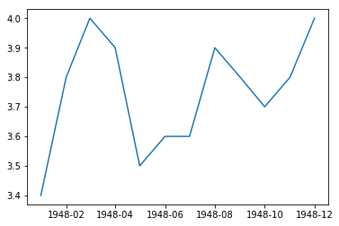

```python
import matplotlib.pyplot as plt
first_year = unrate[0:12]

plt.plot(first_year['DATE'], first_year['UNRATE'])
plt.show()
```

## Créer une rotation sur les données de l'axe x

- Générer le même graphique linéaire pour visualiser le taux de chômage en 1948:
  > - prendre pour x les 12 premières valeurs de la colonne 'DATE'
  > - prendre pour y les 12 premières valeurs de la colonne 'UNRATE'
- Utiliser la fonction pyplot.xticks() pour créer une roration de 90 degrés.
- Afficher le graphique.

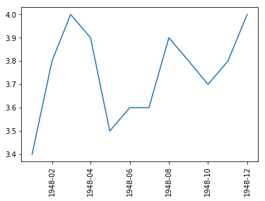

```python
plt.plot(first_year['DATE'], first_year['UNRATE'])
plt.xticks(rotation=90)
plt.show()
```

## Ajouter les intitulés des axes et un titre à notre graphique

- Générer le même graphique que précédemment en ajoutant les intitulés des axes x et y ainsi que le titre.
- Définir le nom de l'axe x par "Mois".
- Définir le nom de l'axe y par "Taux de chômage (%)".
- Définir le titre par "Evolution du taux de chômage en 1948 aux USA".
- Afficher le graphique.

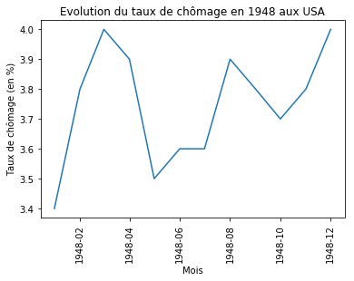

```python
plt.plot(first_year['DATE'], first_year['UNRATE'])
plt.xticks(rotation=90)
plt.xlabel('Mois')
plt.ylabel('Taux de chômage (en %)')
plt.title('Evolution du taux de chômage en 1948 aux USA')
plt.show()
```

## Position des graphiques

- Créer 6 graphiques sur 2 lignes et 3 colonnes.

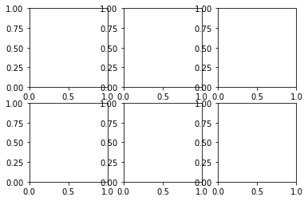

```python
fig = plt.figure()
ax1 = fig.add_subplot(2,3,1)
ax2 = fig.add_subplot(2,3,2)
ax3 = fig.add_subplot(2,3,3)
ax4 = fig.add_subplot(2,3,4)
ax5 = fig.add_subplot(2,3,5)
ax6 = fig.add_subplot(2,3,6)
plt.show()
```

## Ajouter des données aux graphiques

Créer 2 courbes linéaires dans une grille 2 lignes 1 colonne:

- Dans le sous-graphique du haut, tracer les données de 1948.
  > - prendre pour l'axe x les 12 premières valeurs de la colonne 'DATE'
  > - prendre pour l'axe y les 12 premières valeurs de la colonne 'UNRATE'
- Dans le sous-graphique du bas, tracer les données de 1949.
  > - prendre pour l'axe x les valeurs d'index 12 à 24 de la colonne 'DATE' (les 12 valeurs suivantes du dataframe)
  > - prendre pour l'axe y les valeurs d'index 12 à 24 de la colonne 'UNRATE'
- utiliser plt.show() pour afficher les 2 graphiques.

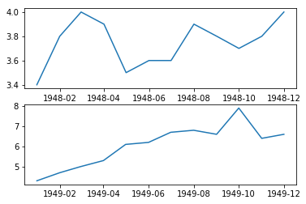

```python
fig = plt.figure()

ax1 = fig.add_subplot(2,1,1)
ax2 = fig.add_subplot(2,1,2)

ax1.plot(unrate[0:12]['DATE'], unrate[0:12]['UNRATE'])
ax2.plot(unrate[12:24]['DATE'], unrate[12:24]['UNRATE'])

plt.show()
```

## Améliorer l'affichage

Pour le précédent graphique, ajouter une largeur de 15 et une hauteur de 8. Et ajouter un titre pour les 2 graphiques:

- pour ax1: "Taux de chômage en 1948"
- pour ax2: "Taux de chômage en 1949"

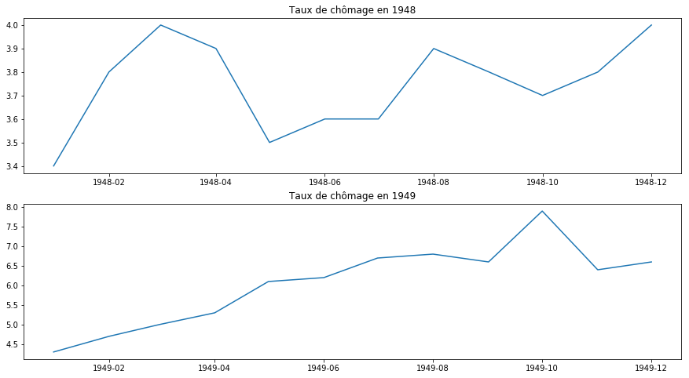

```python
fig = plt.figure(figsize=(15,8))
ax1 = fig.add_subplot(2,1,1)
ax2 = fig.add_subplot(2,1,2)
ax1.plot(unrate[0:12]['DATE'], unrate[0:12]['UNRATE'])
ax1.set_title('Taux de chômage en 1948')
ax2.plot(unrate[12:24]['DATE'], unrate[12:24]['UNRATE'])
ax2.set_title('Taux de chômage en 1949')

plt.show()
```

## Superposition de courbes

- Définir la zone d'affichage à 6 pouces de large et 3 pouces de haut.
- Générer 2 courbes dans un seul graphique en utilisant la colonne 'MONTH' pour l'axe x à la place de la colonne 'DATE':
  > - Une courbe avec les valeurs de 1948 de couleur 'red'
  > - Une courbe avec les valeurs de 1949 de couleur 'blue'
- Utiliser plt.show() pour afficher les courbes.

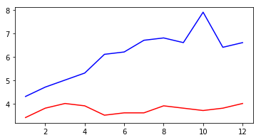

```python
unrate['MONTH'] = unrate['DATE'].dt.month

fig = plt.figure(figsize=(6,3))

plt.plot(unrate[0:12]['MONTH'], unrate[0:12]['UNRATE'], c='red')
plt.plot(unrate[12:24]['MONTH'], unrate[12:24]['UNRATE'], c='blue')

plt.show()
```

## Ajouter plus de courbes

- Définir la zone d'affichage du graphique à 10 pouces de large et 6 pouces de haut.
- Générer les courbes suivantes sur le même graphique:
  > - 1948: courbe en rouge 'red'
  > - 1949: courbe en bleu 'blue'
  > - 1950: courbe en vert 'green'
  > - 1951: courbe en orange 'orange'
  > - 1952: courbe en noir 'black'
- Utiliser plt.show() pour afficher les courbes.

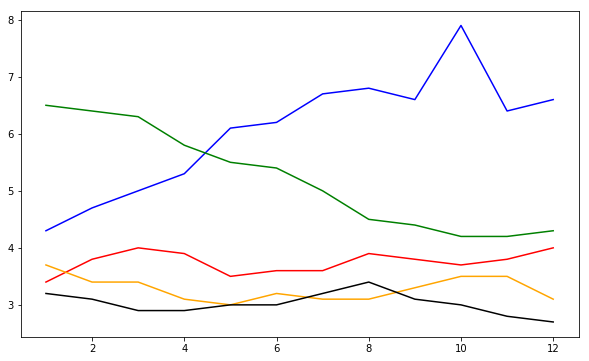

```python
fig = plt.figure(figsize=(10,6))
colors = ['red','blue','green','orange','black']

for i in range(5):
    start_index = i*12
    end_index = (i+1)*12
    subset = unrate[start_index:end_index]

    plt.plot(subset['MONTH'],subset['UNRATE'], c=colors[i])

plt.show()
```

## Ajouter une légende

- Modifier le code précédent pour inclure une légende précisant l'année pour chaque couleur.
  > - C'est-à-dire que la courbe des données de 1948 qui utilise la couleur rouge 'red' aura comme intitulé dans la légende '1948'
- Positionner la légende dans le coin haut et gauche 'upper left'.
- Afficher le graphique.

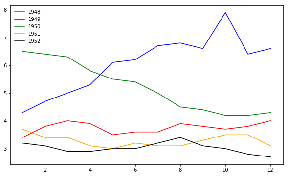

```python
fig = plt.figure(figsize=(10,6))
colors = ['red','blue','green','orange','black']

for i in range(5):
    start_index = i*12
    end_index = (i+1)*12
    subset = unrate[start_index:end_index]
    label = str(1948 + i)
    plt.plot(subset['MONTH'],subset['UNRATE'], c=colors[i], label=label)
plt.legend(loc='upper left')
plt.show()
```

## Courbe final

- Modifier le code précédent afin:
  > - d'ajouter le titre 'Evolution du taux de chômage de 1948 à 1952'
  > - d'ajouter l'intitulé pour l'axe x 'Mois (de 1 à 12)'
  > - d'ajouter l'intitulé pour l'axe y 'Taux de chômage (en %)'

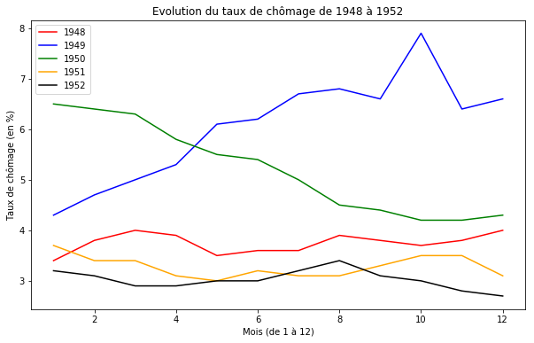

```python
fig = plt.figure(figsize=(10,6))
colors = ['red','blue','green','orange','black']

for i in range(5):
    start_index = i*12
    end_index = (i+1)*12
    subset = unrate[start_index:end_index]
    label = str(1948 + i)
    plt.plot(subset['MONTH'],subset['UNRATE'], c=colors[i], label=label)
plt.legend(loc='upper left')
plt.title('Evolution du taux de chômage de 1948 à 1952')
plt.xlabel('Mois (de 1 à 12)')
plt.ylabel('Taux de chômage (en %)')
plt.show()
```